# Examen Mod 2

Natalia Blanco

2023-06-03

# Preguntas

**Describir los elementos de una matriz de riesgos.**

La matriz de riesgo se utiliza para la medición de riesgos así mismo esta puede ser utilizada para la mitigación de estos. Los elementos que una matriz de riesgo contiene comúnmente son los siguientes:

- Descripción del riesgo
- Probabilidad esta se indica de la siguiente manera dependiendo del riesgo: Alta, muy alta, media, baja, muy baja.
- Impacto se mide si el riesgo es de: Alto, muy alto, medio, bajo o muy bajo impacto.
- Efectividad del mitigante a este también se le asigna una categoría entre muy alto a bajo.
- Riesgo residual, se asigna una categoría entre muy alto y muy bajo.
- Score, se tiene un score de la probabilidad, impacto, efectividad y riesgo residual tomando en cuenta la categoría de estos.

**Describir las diferencias entre un KPI y un KRI.**

Existen múltiples diferencias entre un KPI y un KRI algunas de estas son las siguientes:

- Un KRI esta enfocado a la medición de riesgos, en contraste un KPI esta enfocado a la medición del rendimiento de una empresa.
- Los KRI se definen tomando en cuenta los posibles riesgos que una empresa u organización puede enfrentar, los KPI son definidos en base a las metas y el desempeño que se ha observado.
- Los KRI se enfocan en desarrollar un ambiente proactivo en cuanto a la medición y mitigación de riesgos, los KPI se enfocan en crear un ambiente reactivo.

**Describir la diferencia entre programación lineal y no lineal y los tipos que existen.**

La programación lineal en un método utilizado para maximizar o minimizar una función lineal en nuestro caso y el contexto de la clase sería un proceso el cual está sujeto a un conjunto de restricciones. Por su parte la programación no lineal se utiliza para la optimización de funciones o procesos no lineales en este caso las variables no tienen una combinación lineal.

Existen varios tipos de programación lineal y no lineal estos son los siguientes:

**Describir que es un análisis de sensibilidad y uno de dualidad.**

Ambos se utilizan para comprender y utilizar de una forma eficaz los resultados de un modelo de programación lineal. El análisis de sensibilidad permite evaluar el impacto de cambios en los parámetros sobre la solución optima encontrada. Por otro lado, el análisis de dualidad ofrece una perspectiva alternativa del problema al brindar información acerca de los limites superiores e inferiores de la función objetivo y costo de las restricciones.

**Describir que es un algoritmo genético, el proceso y los elementos que lo componen.**

Los algoritmos genéticos consisten en una técnica de optimización utilizada para resolver problemas complejos mediante la simulación de procesos de selección natural, reproducción y recombinación genética.

El proceso y los elementos que componen un algoritmo genético son los siguientes:

- Población: generar/determinar una población inicial
- Función fitness: calcular función fitness.
- Selección de soluciones padres: seleccionar los dos mejores resultados.
- Crossover: Realizar el crossover utilizando las soluciones padres.
- Mutación: llevar a cabo el proceso de mutación.
- Repetir: Seleccionar una nueva población y realizar nuevamente el proceso a partir de la selección de soluciones padre.
- Criterio de aceptación: Una ves alcanzado el criterio de aceptación detener el proceso.
- Solución óptima: la solución optima es seleccionada en base al mejor fitness value.

**Describir el método de Monte Carlo.**

El método Montecarlo es una técnica de simulación, esta utiliza números aleatorios para resolver problemas o estimar resultados numéricos. Su proceso consiste en generar muestras aleatorias y realizar cálculos o aproximaciones utilizando estadísticas de dichas muestras.

**Describir el método de Bootstrapping.**

El Bootstrapping es un método estadístico que permite estimar la incertidumbre de un estimador así mismo es utilizado para realizar inferencias sobre una muestra de datos. Su proceso consiste en la generación de múltiples muestras de datos las cuales son generadas a partir de una muestra original por medio del muestreo con remplazo a partir de esto se simula la variabilidad de la población subyacente.

## Referencias

- Leite, B. S. C. F. (2023, May 8). Nonlinear programming: Theory and applications - Towards Data Science. Medium. https://towardsdatascience.com/nonlinear-programming-theory-and-applications-cfe127b6060c
- Módulo 2- Algoritmos geneticos.pdf
- Modulo 2 Aplicación de sistemas de riesgos.pdf
- Módulo 2 - Tipos de modelo de optimización.pdf
- Vella, D. C. (2021). Sensitivity Analysis and Duality. In Cambridge University Press eBooks (pp. 148–184). https://doi.org/10.1017/9781108568166.006

# Ejercicios

### 2. Calcular la utilidad neta estimada mediante el método de Monte Carlo. Asumir un volumen de ventas de 500, un precio de venta de 150 y un costo fijo de 15,000. El costo unitario sigue una distribución normal con una desviación estándar de 65 y una media de 45. Finalmente, considerar la siguiente fórmula para el calculo de la utilidad estimada:

**Utilidad Neta = Volumen Ventas * (Precio Venta – Costo Unitario) – Costo Fijo**

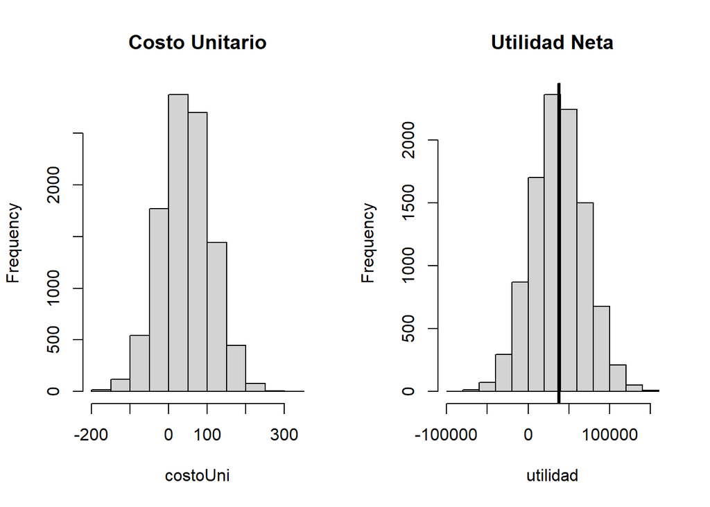

```r
#Parámetros
volumen <- 500
precio <- 150
costo <- 15000
mediaCostoU <- 45
dve <- 65
muestras <- 10000
utilidad<-vector(mode="numeric")
costoUni<-vector(mode="numeric")

#Generamos las muestras aleatorias
for (i in 1:muestras)
{
  costoUnitario <- rnorm(1, mediaCostoU, dve)

  # Calculamos la utilidad neta estimada para cada muestra
  utilidad_neta_estimada <- volumen * (precio - costoUnitario) - costo

  utilidad[i]=utilidad_neta_estimada
  costoUni[i]=costoUnitario
}

#Calcular la utilidad neta promedio estimada
par(mfrow=c(1,2))
hist(costoUni, main="Costo Unitario")
hist(utilidad, main="Utilidad Neta")
abline(v=mean(utilidad),col=1.8,lwd=3)
```

```r
summary(costoUni)
```

```
##      Min.   1st Qu.    Median      Mean   3rd Qu.      Max.
## -198.8874    0.9695   44.9104   44.9682   88.7234  303.5404
```

```r
summary(utilidad)
```

```
##    Min. 1st Qu.  Median    Mean 3rd Qu.    Max.
##  -91770   15638   37545   37516   59515  159444
```

```r
#Resultados
cat("Utilidad Neta Estimada:", mean(utilidad))
```

```
## Utilidad Neta Estimada: 37515.9
```